# A3: SPL Library Checkouts in relation to the novel, Normal People

Connor Chan

### Introduction

For Assignment 3, I am examining data from the Seattle Public Library, more specifically checkout data from the novel, Normal People, written by Sally Rooney. The dataset I chose from the public library includes both univariate and multivariate categories including Usage Class, Checkout Type, Material Type, Checkout Year, Checkout Month, number of checkouts, Title, ISBN, author, genre, Publisher, and Publication Year.

I am choosing to examine this dataset because I am currently reading Normal People, and I am interested in learning about the popularity of the novel between its publish date and today.

### Summary Information

For research questions, I drew questions from the inspiration section of the dataset as well as from my personal interests. All of my questions are related to the dataset chosen regarding the novel, Normal People.

1. What is the average number of checkouts?

Answer: 122.8106

2. What month has the most checkouts?

Answer: May; 1644 checkouts

3. What year has the least amount of checkouts?

Answer: 2023; 151 checkouts

These 5 questions allowed me to properly examine the data, allowing me to make new discoveries about checkout data regarding the novel, Normal People at the Seattle Public Library.

### The Dataset

#### Who collected/published the data?

The Seattle Public Library

#### What are the parameters of the data (dates, number of checkouts, kinds of books, etc.)?

The parameters within the dataset include Usage Class, Checkout Type, Material Type, Checkout Year, Checkout Month, number of checkouts, Title, ISBN, author, genre, Publisher, and Publication Year.

#### How was the data collected or generated?

The data was collected and generated by the Seattle Public Library database

#### Why was the data collected?

The data was collected to look at the checkout data at the Seattle Public Library, to allow open knowledge access to the public, this data allows people to visualize trends in data and various categories.

#### What, if any, ethical questions do you need to consider when working with this data?

The data collected from the Seattle Public Library between April 2019 and February 2023 is unbiased data, collected through checkout machines. However, it is important to consider possible ethical questions that may change data accuracy, some of which include: people taking books without proper checking out and machine malfunction. When working with this data to answer the questions at hand, it is important to weigh the accuracy of data. In this specific instance, it is most likely that the data is accurate.

#### What are possible limitations or problems with this data? (at least 200 words)

The Normal People dataset from the Seattle Public Library represents a single library. As a result, the data does not accurately reflect checkout patterns across global libraries and data systems. For example, if the library serves a unique demographic or has a specific collection, the observed patterns will not represent all checkout patterns.

The Normal People dataset may also suffer from potential errors and inconsistencies in the data collection process. For example, there may be discrepancies in how checkout data has been recorded or there may be different methods used to count checkouts. These manual and technical issues could lead to inaccuracies in the dataset and may impact the validity of conclusions drawn from the data. As a result, it is important to carefully review the data and consider potential sources of error before drawing any definitive conclusions.

### First Trends Over Time Chart

I made a line chart that represents checkout data over time, because I was interested in seeing how different material types fluctuated in popularity since 2019.

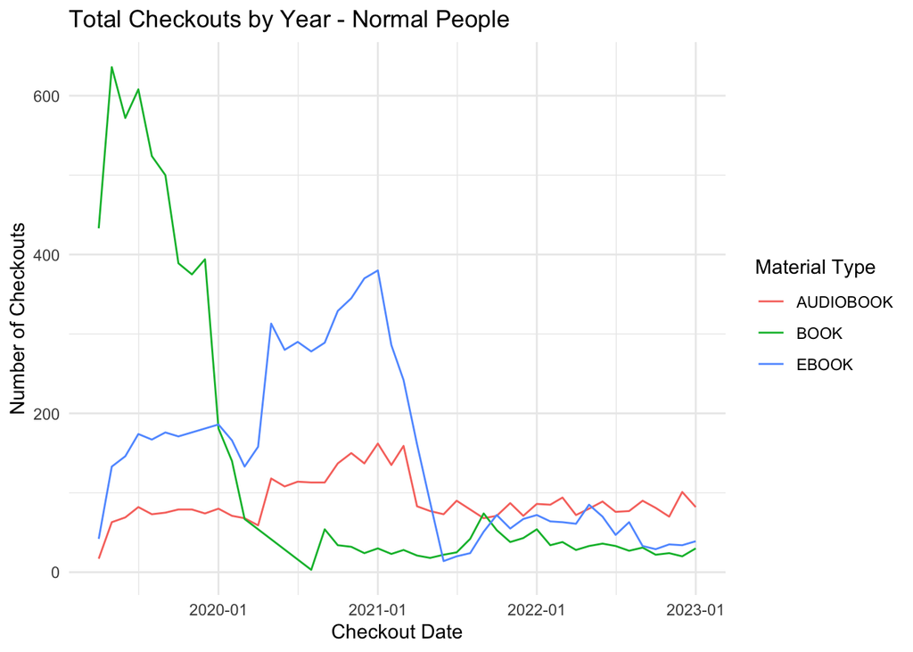

### Second Trends Over Time Chart

I decided to make a stacked bar chart to measure the number of checkouts over time in addition to material type.The chart helps to identify patterns in the checkout data over the years 2019 to early 2023.From the chart, we can see a shift in popularity of material types between 2019 and 2020. This is the same trend we visualized in our line first line chart. Additionally, there is a steady decrease in popularity of checkouts from the Seattle Public Library. This result may be from various reasons including COVID-19, a decreasing interest in the novel, technological issues, etc.

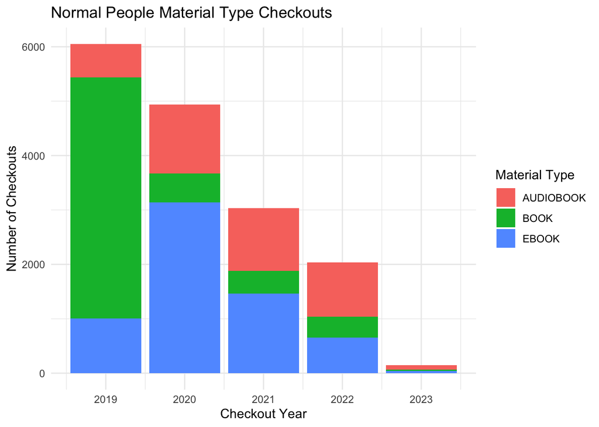

### My Choice

The chart displays a pie chart with the title “Material Type Breakdown of Checkouts (2019-2023). The pie chart shows the total checkouts for each material type, with each material type represented by a different colored slice of the pie. The pie chart allows use to see the full material type breakdown between 2019 and 2023. This chart evaluates which material types are most popular and less popular.

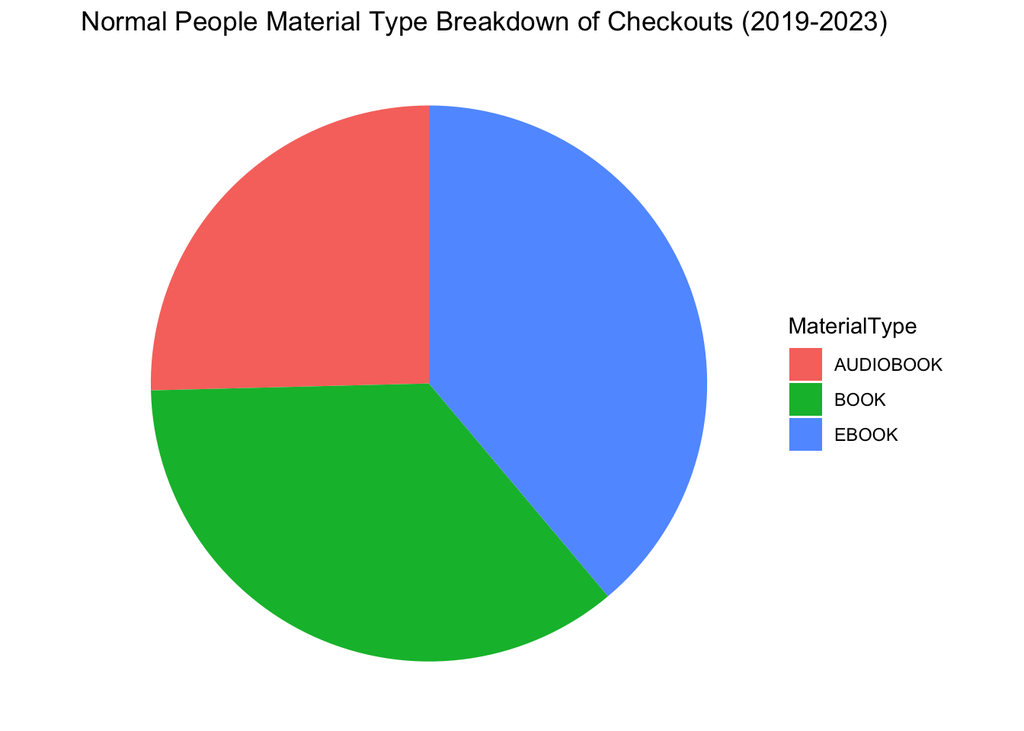